# Title TBD

# Exploratory Analysis

```r
summary(acs_with_access$chargers_accessible)
```

```
   Min. 1st Qu.  Median    Mean 3rd Qu.    Max.
  0.000   0.000   2.000   8.378   7.000 595.000
```

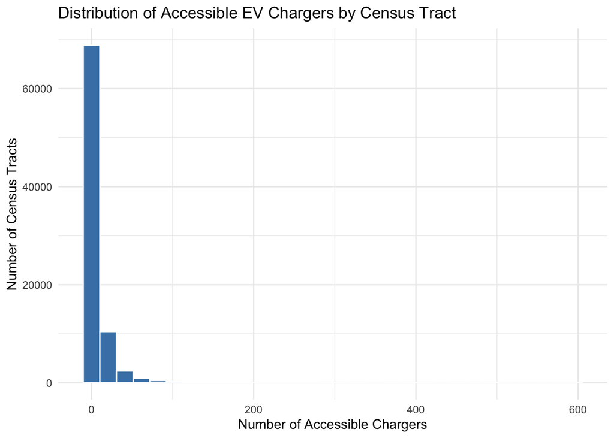

```r
acs_with_access %>%
  ggplot(aes(x = chargers_accessible)) +
  geom_histogram(bins = 30, fill = "steelblue", color = "white") +
  labs(
    title = "Distribution of Accessible EV Chargers by Census Tract",
    x = "Number of Accessible Chargers",
    y = "Number of Census Tracts"
  ) +
  theme_minimal()
```

# Exploring Predictors of Charger Access

## Linear Model

We start with a simple OLS model. Here we opt for log chargers as our dependent variable, due to the long tail of in the distribution of charger counts. Because we are interested in the relative importance of our predictors, not their specific coefficients, we opt to normalise our variables for a cleaner comparison.

### Defining and Fitting the Model

First we select a limited amount of variables as potential predictors, and eliminate other variables that may be duplicative or irrelevant. This collection of predictors is used across all three models.

```r
predictors <- c(
  "pop_density",
  "med_hh_income",
  "pct_white_nh",
  "pct_black_nh",
  "pct_asian_nh",
  "pct_hispanic",
  "pov_rate",
  "unemprate",
  "renter_share",
  "multifam_share",
  "zero_veh_share",
  "commute_car_share"
)
```

Then we create a clean dataframe, dropping geometry, and logging the count of chargers. We then define and fit the model.

```r
lm_df <- acs_with_access %>%
  sf::st_drop_geometry() %>%
  mutate(log_chargers = log1p(chargers_accessible)) %>%
  select(log_chargers, all_of(predictors)) %>%
  drop_na()

lm_rec_std <- recipe(log_chargers ~ ., data = lm_df) %>%
  step_normalize(all_predictors())

lm_spec <- linear_reg() %>%
  set_engine("lm")

lm_wf_std <- workflow() %>%
  add_recipe(lm_rec_std) %>%
  add_model(lm_spec)

lm_fit_std <- fit(lm_wf_std, data = lm_df)
```

### Evaluating the Model

Because we use the count of chargers as our dependent variable with this model, we can’t evaluate accuracy, recall, and precision the way we do with our decision tree and LASSO models later. However, we can look at the model’s R^2 to roughtly understand how much of the variation in charger counts our model accounts for.

```r
glance(lm_fit_std) %>%
  select(r.squared, adj.r.squared, nobs)
```

```
# A tibble: 1 × 3
  r.squared adj.r.squared  nobs
      <dbl>         <dbl> <int>
1     0.407         0.407 82916
```

We see that the model captured about 41% of the variation in charger counts. Substantial, but low enough to suggest there are other variables we aren’t accounting for that play a significant role in determining counts.

### Evaluating Variable Importance

To evaluate the importance of our predictors, we look at their coefficients. Since they have been normalized, we can easily compare them.

```r
lm_coef_table_std <- tidy(lm_fit_std) %>%
  filter(term != "(Intercept)") %>%
  mutate(
    signif = case_when(
      p.value < 0.001 ~ "***",
      p.value < 0.01 ~ "**",
      p.value < 0.05 ~ "*",
      p.value < 0.1 ~ "x",
      TRUE ~ ""
    ),
    estimate = round(estimate, 3),
    std.error = round(std.error, 3),
    p.value = round(p.value, 3)
  ) %>%
  arrange(desc(abs(estimate))) %>%
  select(term, estimate, std.error, p.value, signif)

lm_coef_table_std
```

```
# A tibble: 12 × 5
   term              estimate std.error p.value signif
   <chr>                <dbl>     <dbl>   <dbl> <chr>
 1 renter_share         0.416     0.006   0     "***"
 2 med_hh_income        0.298     0.005   0     "***"
 3 commute_car_share   -0.259     0.005   0     "***"
 4 multifam_share       0.235     0.005   0     "***"
 5 pct_asian_nh         0.119     0.007   0     "***"
 6 pop_density         -0.092     0.005   0     "***"
 7 pct_hispanic         0.084     0.012   0     "***"
 8 pct_black_nh        -0.055     0.011   0     "***"
 9 zero_veh_share      -0.04      0.006   0     "***"
10 pov_rate            -0.032     0.005   0     "***"
11 unemprate            0.014     0.004   0     "***"
12 pct_white_nh        -0.004     0.016   0.797 ""
```

With the exception of `pct_white_nh`, the percentage of the tract’s population which is white (Non-Hispanic/Latino), all of our predictors are highly significant.

A simple visualization makes the comparison more clear:

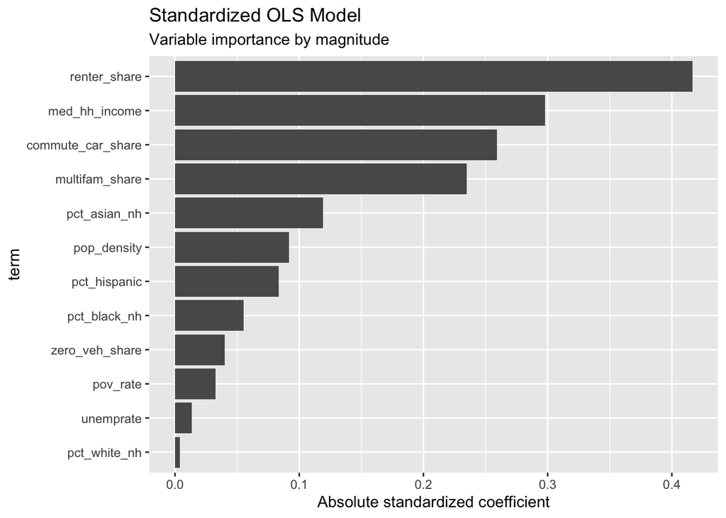

```r
plot_df_mag <- tidy(lm_fit_std) %>%
  filter(term != "(Intercept)") %>%
  mutate(
    mag = abs(estimate),
  ) %>%
  arrange(mag) %>%
  mutate(term = factor(term, levels = term))

lm_vi_plot <- ggplot(plot_df_mag, aes(x = mag, y = term)) +
  geom_col() +
  labs(
    x = "Absolute standardized coefficient",
    title = "Standardized OLS Model",
    subtitle = "Variable importance by magnitude"
  )

lm_vi_plot
```

(Importantly, this shows the absolute value of the magintude of each coefficient, though some variables had a negative impact on number of available chargers.)

The variable importance results suggest that charger deployment is being driven less by simple population metrics and more by housing type, travel behavior, and market conditions. The strongest positive predictors are renter share, median household income, and multifamily housing share. This pattern is intuitive. Renters and residents of multifamily buildings are less likely to have access to private, at home charging, which increases demand for public or shared chargers. At the same time, higher income areas are more likely to attract early infrastructure investment, either because residents are more likely to own EVs or because these neighborhoods have greater resources to support deployment.

Commute by car share plays a strongly negative role, which is consistent with the fact that our analysis focuses only on public chargers. In areas where a larger share of residents commute by car, households are more likely to have access to private parking and private chargers, reducing reliance on public infrastructure. Population density plays a smaller and negative role, suggesting that density alone does not guarantee more chargers. This makes sense, considering that in very dense urban neighborhoods, limited curb space, older infrastructure, and more complex permitting constraints can make deployment more difficult. This helps explain why both high commute by car share and high zero vehicle share are associated with fewer public chargers. On one end are tracts where private vehicles, parking, and home charging are common. On the other are dense urban tracts with fewer cars but greater physical and regulatory barriers. In both cases, demand for or feasibility of public chargers are lower.

The smaller effects for race, poverty, and related variables are harder to interpret directly and likely reflect broader neighborhood characteristics correlated with housing form, land use, and infrastructure conditions rather than intentional targeting.

## Decision Tree Model

We create a dataframe for use with this model, dropping grometries which are not needed for this analysis, and selecting the same set of predictors used in the previous model. We drop census tracks with NA values. We then split the data into testing and training sets.

```r
tree_model_df <- acs_with_access %>%
  st_drop_geometry() %>%
  select(charger_cat, all_of(predictors)) %>%
  na.omit()

# create a split object
tree_model_df_split <- initial_split(data = tree_model_df, prop = 0.75, strata = charger_cat)

# create the training and testing data sets
tree_model_df_train <- training(x = tree_model_df_split)
tree_model_df_test  <- testing(x = tree_model_df_split)
```

We fit a classification tree using rpart and set two regularization parameters to keep the model from chasing noise. The complexity parameter `(cp = 0.005)` so that a split is only kept if it improves model fit by at least about 0.5%, which discourages lots of small, low-value splits and produces a tree that is easier to interpret. We also set `minsplit = 250`, meaning a node must contain at least 250 training observations before it can be split.

```r
tree_rec <- recipe(charger_cat ~ ., data = tree_model_df_train)

tree_model <- decision_tree(mode = "classification") |>
  set_engine(
    "rpart",
    control = rpart.control(cp = 0.005, minsplit = 250)
  )

tree_wf <- workflow() |>
  add_recipe(tree_rec) |>
  add_model(tree_model)

# fit
rpart_fit <- tree_wf |>
  fit(data = tree_model_df_train)
```

### Evaluating the Model

We evaluate our model using the testing set, calculating precision, recall, and accuracy for both sets.

```r
train_preds <- predict(rpart_fit, tree_model_df_train, type = "class") |>
  bind_cols(tree_model_df_train)

test_preds <- predict(rpart_fit, tree_model_df_test, type = "class") |>
  bind_cols(tree_model_df_test)

tree_model_metrics <- tibble(
  train_precision = precision(data = train_preds, truth = charger_cat, estimate = .pred_class)$.estimate,
  train_recall    = recall(data = train_preds, truth = charger_cat, estimate = .pred_class)$.estimate,
  train_accuracy  = accuracy(data = train_preds, truth = charger_cat, estimate = .pred_class)$.estimate,
  test_precision  = precision(data = test_preds, truth = charger_cat, estimate = .pred_class)$.estimate,
  test_recall     = recall(data = test_preds, truth = charger_cat, estimate = .pred_class)$.estimate,
  test_accuracy   = accuracy(data = test_preds, truth = charger_cat, estimate = .pred_class)$.estimate
)

tree_model_metrics
```

```
# A tibble: 1 × 6
  train_precision train_recall train_accuracy test_precision test_recall
            <dbl>        <dbl>          <dbl>          <dbl>       <dbl>
1           0.435        0.350          0.386          0.435       0.351
# ℹ 1 more variable: test_accuracy <dbl>
```

### Evaluating Variable Importance

We examine variable importance from the fitted classification tree to understand which features the model relies on most when splitting observations.

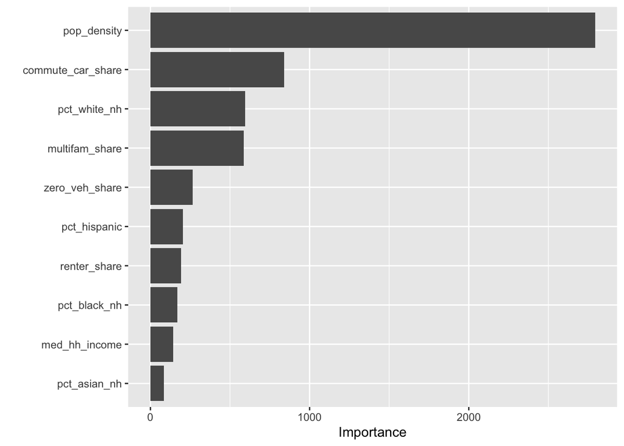

```r
rpart_fit |>
  extract_fit_parsnip() |>
  vip()
```

In this model, population density dominates, indicating that density is the single most useful first cut for distinguishing between tracts with very low versus nonzero charger counts. This reflects the tree’s structure. It prioritizes variables that best split the data early, rather than distributing explanatory power across a collection of variables, as in the linear model. Density likely serves as a proxy for a group of conditions that matter for charger placement, including land use, commercial activity, and overall demand.

After splitting on density, the tree places greater weight on multifamily housing share and commute by car share. This suggests that once a tract clears a basic density threshold, housing form and travel behavior help explain where chargers are more likely to be deployed within similarly dense areas. Variables that were important in the linear model, such as renter share and income, appear less prominent here likely because they overlap strongly with density and housing type and add less predictive power after the initial splits.

The relatively small importance of most demographic variables suggests that the tree is capturing broad structural features of neighborhoods rather than narrow socioeconomic targeting. That said, the model places somewhat greater weight on a tract’s white population share. This likely reflects the role of race as a proxy for neighborhood type in a context shaped by longstanding residential segregation. White share may be picking up structural differences in neighborhood types, land use, and infrastructure that are only partially captured by variables like population density or multifamily housing share, rather than suggesting any direct discrimination in charger placement based on demographic characteristics.

## LASSO Model

Our third model is a LASSO model specified as a multinomial logistic regression predicting charger density category (charger_cat). This approach allows us to examine how the importance of different tract characteristics varies across charger density levels, rather than estimating a single average relationship across the entire dataset. In addition, the LASSO penalty provides a robustness check by shrinking weaker or redundant predictors, helping highlight which variables remain important for distinguishing between charger density categories.

### Defining and Fitting the Model

We use the same collection of predictors for our LASSO model, and split the data in the same way. We also confirm that our variable `charger_cat` is encoded as a factor.

```r
lasso_df <- acs_with_access %>%
  st_drop_geometry() %>%
  select(charger_cat, all_of(predictors)) %>%
  na.omit() %>%
  mutate(charger_cat = factor(charger_cat))

set.seed(20201020)

lasso_df_split <- initial_split(data = lasso_df, prop = 0.75, strata = charger_cat)

lasso_df_train <- training(x = lasso_df_split)
lasso_df_test <- testing(x = lasso_df_split)
```

We define a multinomial LASSO model and estimate it using 5 fold cross validation with a 30 value tuning grid. We evaluate model performance using log loss, which accounts not only for whether the model predicts the correct category, but also how confident it is in its predictions.

```r
lasso_rec <- recipe(charger_cat ~ ., data = lasso_df_train) %>%
  step_normalize(all_numeric_predictors())

lasso_spec <- multinom_reg(penalty = tune(), mixture = 1)%>%
  set_engine("glmnet")

lasso_wf <- workflow() %>%
  add_recipe(lasso_rec) %>%
  add_model(lasso_spec)

folds <- vfold_cv(lasso_df_train, v = 5, strata = charger_cat)

lambda_grid <- grid_regular(penalty(), levels = 30)

lasso_tuned <- tune_grid(
  lasso_wf,
  resamples = folds,
  grid = lambda_grid,
  metrics = metric_set(accuracy, mn_log_loss)
)

best_lambda <- select_best(
  lasso_tuned,
  metric = "mn_log_loss"
)
```

Notably, our optimal lambda is very small at 0.0000000001. This suggests our predictors are already doing a good job explaining charger categories require only minimal regularization.

```r
best_lambda
```

```
# A tibble: 1 × 2
       penalty .config
         <dbl> <chr>
1 0.0000000001 pre0_mod01_post0
```

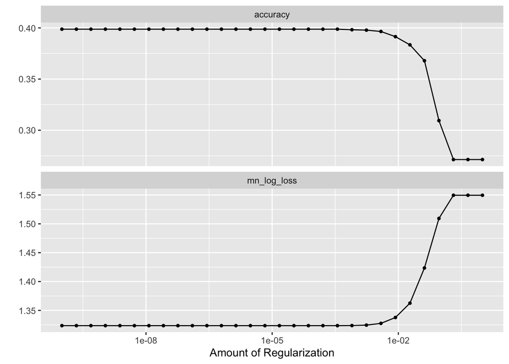

```r
autoplot(lasso_tuned)
```

We then fit the model and store its predictions for evaluation.

```r
final_lasso <- finalize_workflow(lasso_wf, best_lambda) %>%
  fit(data = lasso_df_train)

lasso_train_preds <- predict(final_lasso, lasso_df_train, type = "class") %>%
  bind_cols(lasso_df_train)

lasso_test_preds <- predict(final_lasso, lasso_df_test, type = "class") %>%
  bind_cols(lasso_df_test)
```

### Evaluating the Model

```r
lasso_model_metrics <- tibble(
  train_precision = precision(lasso_train_preds, truth = charger_cat, estimate = .pred_class)$.estimate,
  train_recall    = recall(lasso_train_preds, truth = charger_cat, estimate = .pred_class)$.estimate,
  test_precision  = precision(lasso_test_preds, truth = charger_cat, estimate = .pred_class)$.estimate,
  test_recall     = recall(lasso_test_preds, truth = charger_cat, estimate = .pred_class)$.estimate,
  train_accuracy  = accuracy(lasso_train_preds, truth = charger_cat, estimate = .pred_class)$.estimate,
  test_accuracy   = accuracy(lasso_test_preds, truth = charger_cat, estimate = .pred_class)$.estimate
)

lasso_model_metrics
```

```
# A tibble: 1 × 6
  train_precision train_recall test_precision test_recall train_accuracy
            <dbl>        <dbl>          <dbl>       <dbl>          <dbl>
1           0.376        0.372          0.369       0.373          0.399
# ℹ 1 more variable: test_accuracy <dbl>
```

Though its performance is modest, results are consistent across the training and test sets, suggesting that the model is not overfitting. Notably, accuracy is similar to that of the decision tree model and to the R^2 from the linear specification. While these metrics are not directly comparable, their similarity suggests that we may be reaching the limits of what our selected predictors can explain about charger deployment.

### Evaluating Variable Importance

Because our dependent variable is categorical, the model estimates separate coefficients for each charger density category. The table below reports coefficient estimates for all predictors across the five charger density categories.

```r
coef_tbl <- final_lasso %>%
  extract_fit_parsnip() %>%
  tidy() %>%
  select(class, term, estimate) %>%
  filter(term != "(Intercept)") %>%
  group_by(class) %>%
  arrange(desc(abs(estimate)), .by_group = TRUE) %>%
  print(n=60)
```

```
# A tibble: 60 × 3
# Groups:   class [5]
   class        term               estimate
   <chr>        <chr>                 <dbl>
 1 High         renter_share       0.355
 2 High         commute_car_share -0.256
 3 High         med_hh_income      0.230
 4 High         multifam_share     0.125
 5 High         pct_asian_nh       0.108
 6 High         pov_rate          -0.100
 7 High         pct_hispanic       0.0898
 8 High         zero_veh_share    -0.0332
 9 High         pct_black_nh      -0.0324
10 High         unemprate          0.00826
11 High         pct_white_nh       0.000204
```

[output cut: 49 more lines]

These results largely reinforce the patterns we saw in the linear and tree based models, while adding more detail about how different variables matter at different points along the charger density spectrum. The clearest structure appears at the extremes. Tracts with no chargers are strongly characterized by lower renter share, lower multifamily housing share, lower income, and lower density, alongside higher commute by car share. In other words, places with predominantly single family housing, private vehicles, and private parking are systematically less likely to host public chargers. On the opposite end, very high charger density tracts show the mirror image of this pattern: higher renter share, higher income, more multifamily housing, and lower commute by car share. These are precisely the environments where demand for shared charging is highest and deployment is most feasible, which aligns closely with our earlier interpretations.

The plot below visualizes these coefficients, showing both the average and maximum coefficient across classes.

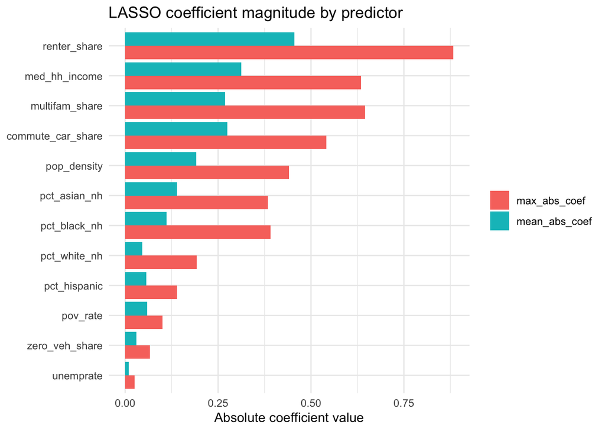

```r
lasso_viz_df <- coef_tbl %>%
  filter(term != "(Intercept)") %>%
  group_by(term) %>%
  summarise(
    max_abs_coef  = max(abs(estimate)),
    mean_abs_coef = mean(abs(estimate)),
    .groups = "drop"
  ) %>%
  arrange(desc(max_abs_coef))

lasso_viz_long <- lasso_viz_df %>%
  pivot_longer(
    cols = c(max_abs_coef, mean_abs_coef),
    names_to = "metric",
    values_to = "value"
  )

lasso_viz <- ggplot(lasso_viz_long,
       aes(x = reorder(term, value), y = value, fill = metric)) +
  geom_col(position = "dodge") +
  coord_flip() +
  labs(
    title = "LASSO coefficient magnitude by predictor",
    x = NULL,
    y = "Absolute coefficient value",
    fill = NULL
  ) +
  theme_minimal()

lasso_viz
```

## Discussion

# Conclusion